# Problem Set 3

Author

Yipeng Liu

# Homework 3

Github Page: https://github.com/EfraimLYP/stats506

## Problem 1

### Step 1

First, use R to read this .XPT file and store it locally as a Stata-readable .dta file.

```r
library(haven)

# Read the .XPT file
vix_D_data <- read_xpt("/Users/yipengliu/Desktop/Graduate Courses/STATS 506/Homework/Problem Set 3/VIX_D.XPT")

# Store it locally as a .dta file
haven:: write_dta(vix_D_data, "/Users/yipengliu/Desktop/Graduate Courses/STATS 506/Homework/Problem Set 3/VIX_D.dta")
```

Then, we can read it in Stata.

```stata
use "/Users/yipengliu/Desktop/Graduate Courses/STATS 506/Homework/Problem Set 3/VIX_D.dta", clear
describe
```

Output:

```
. use "/Users/yipengliu/Desktop/Graduate Courses/STATS 506/Homework/Problem Set 3/VIX_D.d
> ta", clear

. describe

Contains data from /Users/yipengliu/Desktop/Graduate Courses/STATS 506/Homework/Problem S
> et 3/VIX_D.dta
 Observations:         6,980
    Variables:            57                  28 Sep 2023 13:26
-----------------------------------------------------------------------------------------
Variable      Storage   Display    Value
    name         type    format    label      Variable label
-----------------------------------------------------------------------------------------
SEQN            double  %10.0g                Respondent sequence number
VIQ110          double  %10.0g                SP has a severe eye infection?
VIQ121          double  %10.0g                Which eye(s) infected?
VIQ130          double  %10.0g                Is SP wearing an eye patch?
VIQ141          double  %10.0g                Which eye has eye patch?
VIQ150          double  %10.0g                Glasses/contact lenses for near work?
VIQ160          double  %10.0g                Glasses/contact lenses available?
VIQ170          double  %10.0g                Glasses or contacts worn for near test?
VIXNC1          double  %10.0g                Line read on near card
VIXNC2          double  %10.0g                Testing distance of near card
VIQ180          double  %10.0g                Eye surgery for near sightedness?
VIQ191          double  %10.0g                Which eye(s) surgery - near-sightedness?
VIQ200          double  %10.0g                Eye surgery for cataracts?
VIQ211          double  %10.0g                Which eye(s) cataract surgery?
VIQ220          double  %10.0g                Glasses/contact lenses worn for distance
VIQ230          double  %10.0g                Is distance correction available?
VIQ240          double  %10.0g                Which type? Glasses or contacts?
VIQ250          double  %10.0g                Was prescription obtained?
VIXPRS          double  %10.0g                Prescription, right sphere
VIXPRC          double  %10.0g                Prescription, right cylinder
VIXPRA          double  %10.0g                Prescription, right axis
VIXPLS          double  %10.0g                Prescription, left sphere
VIXPLC          double  %10.0g                Prescription, left cylinder
VIXPLA          double  %10.0g                Prescription, left axis
VIXOCMT         double  %10.0g                Visual Acuity Comments
VIXORSM         double  %10.0g                OR right sphere, median
VIXORCM         double  %10.0g                OR right cylinder, median
```

[output cut: 20 more lines]

```
VIXKLD2         double  %10.0g                Left keratometry power steep curve (D)
VIXKLG2         double  %10.0g                Left keratometry axis steep curve (deg)
VIXKLMM         double  %10.0g                Left keratometry radius, average (mm)
VIXKLDM         double  %10.0g                Left keratometry power, average (D)
VIXKLCD         double  %10.0g                Left keratometry cylinder
VIXKLCG         double  %10.0g                Left keratometry axis (deg)
VIDRVA          double  %10.0g                Right visual acuity, presenting
VIDLVA          double  %10.0g                Left visual acuity, presenting
VIDROVA         double  %10.0g                Right visual acuity, w/ obj. refraction
VIDLOVA         double  %10.0g                Left visual acuity, w/ obj. refraction
-----------------------------------------------------------------------------------------
Sorted by:

.
end of do-file
```

Do the same for the DEMO_D data.

```r
# Read the .XPT file
demo_D_data <- read_xpt("/Users/yipengliu/Desktop/Graduate Courses/STATS 506/Homework/Problem Set 3/DEMO_D.XPT")

# Store it locally as a .dta file
haven:: write_dta(demo_D_data, "/Users/yipengliu/Desktop/Graduate Courses/STATS 506/Homework/Problem Set 3/DEMO_D.dta")
```

Finally, we merge the two files to create a single Stata data set, using the SEQN variable for merging and keeping only records which matched.

```stata
merge 1:1 SEQN using "/Users/yipengliu/Desktop/Graduate Courses/STATS 506/Homework/Problem Set 3/DEMO_D.dta"
keep if _merge == 3
count
```

Output:

```
. merge 1:1 SEQN using "/Users/yipengliu/Desktop/Graduate Courses/STATS 506/Homework/Prob
> lem Set 3/DEMO_D.dta"

    Result                      Number of obs
    -----------------------------------------
    Not matched                         3,368
        from master                         0  (_merge==1)
        from using                      3,368  (_merge==2)

    Matched                             6,980  (_merge==3)
    -----------------------------------------

. keep if _merge == 3
(3,368 observations deleted)

. count
  6,980

.
end of do-file
```

### Step 2

Now, without fitting any models, we estimate the proportion of respondents within each 10-year age bracket (e.g. 0-9, 10-19, 20-29, etc) who wear glasses/contact lenses for distance vision.

First, we create a new column in the data set to store the 10-year age bracket of each observation.

```stata
gen age_bracket = int(RIDAGEYR/10)
gen age_bracket_str = ""
replace age_bracket_str = "10-19" if age_bracket == 1
replace age_bracket_str = "20-29" if age_bracket == 2
replace age_bracket_str = "30-39" if age_bracket == 3
replace age_bracket_str = "40-49" if age_bracket == 4
replace age_bracket_str = "50-59" if age_bracket == 5
replace age_bracket_str = "60-69" if age_bracket == 6
replace age_bracket_str = "70-79" if age_bracket == 7
replace age_bracket_str = "80-89" if age_bracket == 8
```

Output:

```
. gen age_bracket = int(RIDAGEYR/10)

. gen age_bracket_str = ""
(6,980 missing values generated)

. replace age_bracket_str = "10-19" if age_bracket == 1
variable age_bracket_str was str1 now str5
(2,207 real changes made)

. replace age_bracket_str = "20-29" if age_bracket == 2
(1,021 real changes made)

. replace age_bracket_str = "30-39" if age_bracket == 3
(818 real changes made)

. replace age_bracket_str = "40-49" if age_bracket == 4
(815 real changes made)

. replace age_bracket_str = "50-59" if age_bracket == 5
(631 real changes made)

. replace age_bracket_str = "60-69" if age_bracket == 6
(661 real changes made)

. replace age_bracket_str = "70-79" if age_bracket == 7
(469 real changes made)

. replace age_bracket_str = "80-89" if age_bracket == 8
(358 real changes made)

.
end of do-file
```

Then, estimate the proportion of respondents within each 10-year age bracket who wear glasses/contact lenses for distance vision.

```stata
tabulate age_bracket_str VIQ220
```

Output:

```
. tabulate age_bracket_str VIQ220

           | Glasses/contact lenses worn for
age_bracke |             distance
     t_str |         1          2          9 |     Total
-----------+---------------------------------+----------
     10-19 |       670      1,418          0 |     2,088
     20-29 |       306        631          2 |       939
     30-39 |       269        481          0 |       750
     40-49 |       286        487          0 |       773
     50-59 |       335        274          0 |       609
     60-69 |       392        238          0 |       630
     70-79 |       299        148          0 |       447
     80-89 |       208        103          0 |       311
-----------+---------------------------------+----------
     Total |     2,765      3,780          2 |     6,547
```

This output deletes all missing values.

### Step 3

Next, we fit three logistic regression models predicting whether a respondent wears glasses/contact lenses for distance vision.

```stata
keep if VIQ220 == 1 | VIQ220 == 2
gen logicalVIQ220 = (VIQ220 == 1)
```

##### Predictor: age

```stata
logit logicalVIQ220 RIDAGEYR
```

Output:

```
. logit logicalVIQ220 RIDAGEYR

Iteration 0:   log likelihood = -4457.6265
Iteration 1:   log likelihood = -4236.2351
Iteration 2:   log likelihood = -4235.9433
Iteration 3:   log likelihood = -4235.9433

Logistic regression                                     Number of obs =  6,545
                                                        LR chi2(1)    = 443.37
                                                        Prob > chi2   = 0.0000
Log likelihood = -4235.9433                             Pseudo R2     = 0.0497

-------------------------------------------------------------------------------
logicalVIQ220 | Coefficient  Std. err.      z    P>|z|     [95% conf. interval]
--------------+----------------------------------------------------------------
     RIDAGEYR |   .0246729   .0012055    20.47   0.000     .0223101    .0270357
        _cons |   -1.26097   .0534482   -23.59   0.000    -1.365727   -1.156213
-------------------------------------------------------------------------------
```

##### Predictor: age, race, gender

RIDRETH1 should be a factorial variable, so we first have to perform a one-hot encoding on it.

```stata
gen RIDRETH1_1 = (RIDRETH1 == 1)
gen RIDRETH1_2 = (RIDRETH1 == 2)
gen RIDRETH1_3 = (RIDRETH1 == 3)
gen RIDRETH1_4 = (RIDRETH1 == 4)
```

Then we convert RIAGENDR to a boolean variable.

```stata
gen logicalRIAGENDR = (RIAGENDR == 1)
```

Now, we can fit the regression model.

```stata
logit logicalVIQ220 RIDAGEYR RIDRETH1_1 RIDRETH1_2 RIDRETH1_3 RIDRETH1_4 logicalRIAGENDR
```

Output:

```
. logit logicalVIQ220 RIDAGEYR RIDRETH1_1 RIDRETH1_2 RIDRETH1_3 RIDRETH1_4 logicalRIAGEND
> R

Iteration 0:   log likelihood = -4457.6265
Iteration 1:   log likelihood = -4138.3859
Iteration 2:   log likelihood = -4136.8807
Iteration 3:   log likelihood = -4136.8805

Logistic regression                                     Number of obs =  6,545
                                                        LR chi2(6)    = 641.49
                                                        Prob > chi2   = 0.0000
Log likelihood = -4136.8805                             Pseudo R2     = 0.0720

---------------------------------------------------------------------------------
  logicalVIQ220 | Coefficient  Std. err.      z    P>|z|     [95% conf. interval]
----------------+----------------------------------------------------------------
       RIDAGEYR |   .0225742   .0012624    17.88   0.000     .0200999    .0250484
     RIDRETH1_1 |  -.6509919   .1354071    -4.81   0.000    -.9163849   -.3855989
     RIDRETH1_2 |  -.4946699   .1974205    -2.51   0.012     -.881607   -.1077328
     RIDRETH1_3 |   .0179388   .1300575     0.14   0.890    -.2369692    .2728468
     RIDRETH1_4 |    -.38912   .1336348    -2.91   0.004    -.6510394   -.1272006
logicalRIAGENDR |  -.5020895    .053011    -9.47   0.000    -.6059891   -.3981899
          _cons |  -.6835841   .1309719    -5.22   0.000    -.9402844   -.4268839
---------------------------------------------------------------------------------

.
end of do-file
```

##### Predictor: age, race, gender, Poverty Income ratio

The first step is to remove the missing values in the column INDFMPIR.

```stata
drop if missing(INDFMPIR)
```

Output:

```
. drop if missing(INDFMPIR)
(298 observations deleted)
```

Now, we can fit the regression model.

```stata
logit logicalVIQ220 RIDAGEYR RIDRETH1_1 RIDRETH1_2 RIDRETH1_3 RIDRETH1_4 logicalRIAGENDR INDFMPIR
```

```
. logit logicalVIQ220 RIDAGEYR RIDRETH1_1 RIDRETH1_2 RIDRETH1_3 RIDRETH1_4 logicalRIAGEND
> R INDFMPIR

Iteration 0:   log likelihood = -4259.5533
Iteration 1:   log likelihood = -3948.3256
Iteration 2:   log likelihood = -3946.9043
Iteration 3:   log likelihood = -3946.9041

Logistic regression                                     Number of obs =  6,247
                                                        LR chi2(7)    = 625.30
                                                        Prob > chi2   = 0.0000
Log likelihood = -3946.9041                             Pseudo R2     = 0.0734

---------------------------------------------------------------------------------
  logicalVIQ220 | Coefficient  Std. err.      z    P>|z|     [95% conf. interval]
----------------+----------------------------------------------------------------
       RIDAGEYR |   .0221883   .0012949    17.14   0.000     .0196504    .0247263
     RIDRETH1_1 |  -.5327271   .1401516    -3.80   0.000    -.8074192   -.2580349
     RIDRETH1_2 |  -.4167045    .202299    -2.06   0.039    -.8132033   -.0202058
     RIDRETH1_3 |  -.0311981   .1335307    -0.23   0.815    -.2929136    .2305173
     RIDRETH1_4 |  -.3253425   .1372987    -2.37   0.018    -.5944431    -.056242
logicalRIAGENDR |  -.5162712    .054305    -9.51   0.000     -.622707   -.4098355
       INDFMPIR |   .1135978   .0177073     6.42   0.000      .078892    .1483035
          _cons |  -.9671613   .1428519    -6.77   0.000    -1.247146   -.6871767
---------------------------------------------------------------------------------
```

After that, we produce a table presenting the estimated odds ratios for the coefficients in each model, along with the sample size for the model, the pseudo-R square, and AIC values.

Suppose we name these three logistic regression models successively as model1, model2, model3. Based on the output of the above models, we created this table manually.

Before that, we manually set it so that the output of each logistic regression contains the AIC value. For example, in model1:

```
. estat ic

Akaike's information criterion and Bayesian information criterion

-----------------------------------------------------------------------------
       Model |          N   ll(null)  ll(model)      df        AIC        BIC
-------------+---------------------------------------------------------------
           . |      6,545  -4457.627  -4235.943       2   8475.887    8489.46
-----------------------------------------------------------------------------
Note: BIC uses N = number of observations. See [R] BIC note.
```

Next up is a table of results.

```stata
matrix outputTable = J(3, 10, .)
matrix rownames outputTable = "model1" "model2" "model3"
matrix colnames outputTable = "RIDAGEYR" "RIDRETH1_1" "RIDRETH1_2" "RIDRETH1_3" "RIDRETH1_4" "logicalRIAGENDR" "INDFMPIR" "sample size" "pseudo-R square" "AIC value"
matrix outputTable[1, 1] = exp(0.0246729)
matrix outputTable[1, 8] = 6545
matrix outputTable[1, 9] = 0.0497
matrix outputTable[1, 10] = 8475.887
matrix outputTable[2, 1] = exp(0.0225742)
matrix outputTable[2, 2] = exp(-0.6509919)
matrix outputTable[2, 3] = exp(-0.4946699)
matrix outputTable[2, 4] = exp(0.0179388)
matrix outputTable[2, 5] = exp(-0.38912)
matrix outputTable[2, 6] = exp(-0.5020895)
matrix outputTable[2, 8] = 6545
matrix outputTable[2, 9] = 0.0720
matrix outputTable[2, 10] =  8287.761
matrix outputTable[3, 1] = exp(0.0221883)
matrix outputTable[3, 2] = exp(-.5327271)
matrix outputTable[3, 3] = exp(-.4167045)
matrix outputTable[3, 4] = exp(-.0311981)
matrix outputTable[3, 5] = exp(-.3253425)
matrix outputTable[3, 6] = exp(-.5162712)
matrix outputTable[3, 7] = exp(.1135978)
matrix outputTable[3, 8] = 6247
matrix outputTable[3, 9] = 0.0734
matrix outputTable[3, 10] =  87909.808
matrix list outputTable
```

Output:

[output not shown]

### Step 4

We can see that in this logistic regression model, the coefficient fitted value before predictor logicalRIAGENDR is -0.5162712, which suggests that, all else being equal, women are more likely to wear glasses/contact lenses relative to men. In addition, the coefficient fitted value has a p-value very close to 0 in the z-test, indicating that the coefficient is significant, and that the odds of men and women being wears of glasess/contact lenses for distance vision significantly differs.

To test whether the proportion of wearers of glasses/contact lenses for distance vision differs between men and women, we can use a chi-square test, as follows:

```
. tabulate logicalRIAGENDR logicalVIQ220, chi2

logicalRIA |     logicalVIQ220
     GENDR |         0          1 |     Total
-----------+----------------------+----------
         0 |     1,673      1,521 |     3,194
         1 |     1,919      1,134 |     3,053
-----------+----------------------+----------
     Total |     3,592      2,655 |     6,247

          Pearson chi2(1) =  70.1108   Pr = 0.000
```

## Problem 2

### Step 1

First, connect to the database, load the .db file and check the database.

```r
library(DBI)

sakila <- dbConnect(RSQLite::SQLite(), "/Users/yipengliu/Desktop/Graduate Courses/STATS 506/Homework/Problem Set 3/sakila_master.db")
dbListTables(sakila)
```

```
 [1] "actor"                  "address"                "category"
 [4] "city"                   "country"                "customer"
 [7] "customer_list"          "film"                   "film_actor"
[10] "film_category"          "film_list"              "film_text"
[13] "inventory"              "language"               "payment"
[16] "rental"                 "sales_by_film_category" "sales_by_store"
[19] "staff"                  "staff_list"             "store"
```

Find out what language is most common for films aside from English.

```r
gg <- function(x) {
  dbGetQuery(sakila, x)
}

d1 <- gg("
SELECT name, count
  FROM (SELECT l.name AS name, COUNT(l.name) AS count
    FROM film f LEFT JOIN language l
      ON f.language_id = l.language_id
        GROUP BY l.name) AS movie_count
")
d1
```

```
     name count
1 English  1000
```

As we can see, there are no movies other than in English.

### Step 2

Find out what genre of movie is the most common in the data, and how many movies are of this genre.

Approach 1. using SQL query or queries to extract the appropriate table(s), then using regular R to answer the question.

```r
# Find out how many movies are there in each genre
d2 <- gg("
SELECT name, count
  FROM (SELECT c.name AS name, COUNT(c.name) AS count
    FROM film_category fc LEFT JOIN category c
      ON c.category_id = fc.category_id
        GROUP BY c.category_id)
  ORDER BY count DESC
")
d2
```

```
          name count
1       Sports    74
2      Foreign    73
3       Family    69
4  Documentary    68
5    Animation    66
6       Action    64
7          New    63
8        Drama    62
9        Games    61
10      Sci-Fi    61
11    Children    60
12      Comedy    58
13    Classics    57
14      Travel    57
15      Horror    56
16       Music    51
```

```r
# Find out what genre of movie is the most common in the data
d2[d2$count == max(d2$count), 'name']
```

```
[1] "Sports"
```

Approach 2. using a single SQL query to answer the question

```r
d3 <- gg("
SELECT name
  FROM (SELECT c.name AS name, COUNT(c.name) AS count
    FROM film_category fc LEFT JOIN category c
      ON c.category_id = fc.category_id
        GROUP BY c.category_id)
  ORDER BY count DESC
  LIMIT 1
")
d3
```

```
    name
1 Sports
```

### Step 3

Identify which country or countries have exactly 9 customers.

Approach 1. using SQL query or queries to extract the appropriate table(s), then using regular R to answer the question.

```r
# Find how many customers are there in each country
d4 <- gg("
SELECT COUNT(ctm.customer_id) AS count, ctry.country AS country
  FROM customer ctm LEFT JOIN address a
    ON ctm.address_id = a.address_id
  LEFT JOIN city ct
    ON a.city_id = ct.city_id
  LEFT JOIN country ctry
    ON ct.country_id = ctry.country_id
  GROUP BY country
  ORDER BY count DESC
")
d4
```

```
    count                               country
1      60                                 India
2      53                                 China
3      36                         United States
4      31                                 Japan
5      30                                Mexico
6      28                    Russian Federation
7      28                                Brazil
8      20                           Philippines
9      15                                Turkey
10     14                             Indonesia
11     13                               Nigeria
12     13                             Argentina
13     11                          South Africa
14     10                                Taiwan
```

[output cut: 94 more lines]

```r
# Identify which country or countries have exactly 9 customers
d4[d4$count == 9, 'country']
```

```
[1] "United Kingdom"
```

Approach 2. using a single SQL query to answer the question

```r
d5 <- gg("
SELECT country FROM (
  SELECT COUNT(ctm.customer_id) AS count, ctry.country AS country
    FROM customer ctm LEFT JOIN address a
      ON ctm.address_id = a.address_id
    LEFT JOIN city ct
      ON a.city_id = ct.city_id
    LEFT JOIN country ctry
      ON ct.country_id = ctry.country_id
    GROUP BY ctry.country)
  WHERE count = 9
")
d5
```

```
         country
1 United Kingdom
```

## Problem 3

### Step 1

First, load and check the data set.

```r
us500_df <- read.csv("/Users/yipengliu/Desktop/Graduate Courses/STATS 506/Homework/Problem Set 3/us-500.csv",
                     header = TRUE)
```

Calculate the proportion of email addresses are hosted at a domain with TLD “.net”.

```r
# Calculate the total number of email addresses are hosted at a domain with TLD “.net”
net_num <- length(grep(".net$", us500_df$email))

# Calculate the proportion of email addresses that are hosted at a domain with TLD “.net”
net_proportion <- net_num/nrow(us500_df)
net_proportion
```

```
[1] 0.14
```

### Step 2

Calculate the proportion of email addresses that have at least one non alphanumeric character in them.

```r
# Calculate the total number of email addresses that have at least one non alphanumeric character in them
non_alphanum_num <- length(grep("[^[:alnum:]]+", us500_df$email))

# Calculate the proportion of email addresses that have at least one non alphanumeric character in them
non_alphanum_proportion <- non_alphanum_num/nrow(us500_df)
non_alphanum_proportion
```

```
[1] 1
```

### Step 3

Calculate the most common area code amongst all phone numbers.

```r
# Combine all phone numbers in a single vector
all_phones <- c(us500_df$phone1, us500_df$phone2)

# Get the area code for each phone number
all_phones_area <- substr(all_phones, 1, 3)

# Get the most common area code amongst all phone numbers
names(table(all_phones_area))[which.max(table(all_phones_area))]
```

```
[1] "973"
```

### Step 4

Produce a histogram of the log of the apartment numbers for all addresses.

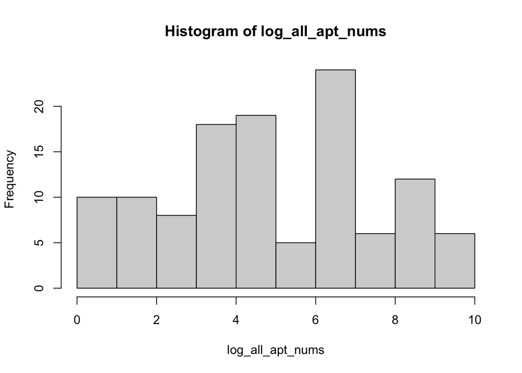

```r
# Get the apartment numbers for all addresses
all_apt_nums <- regmatches(us500_df$address,
                           regexpr("[1234567890]+$",
                                   us500_df$address))

# Get the log of the apartment numbers for all addresses
log_all_apt_nums <- log(as.numeric(all_apt_nums))

# Produce a histogram of the log of the apartment numbers for all addresses
hist(log_all_apt_nums)
```

### Step 5

Examine whether the apartment numbers appear to follow Benford’s law.

```r
library(BenfordTests)
chisq.benftest(as.numeric(all_apt_nums))
```

```
    Chi-Square Test for Benford Distribution

data:  as.numeric(all_apt_nums)
chisq = 52.84, p-value = 1.158e-08
```

It can be seen that there is a significant difference between the observed data and the Benford distribution, i.e. the apartment numbers would not pass as real data.

### Step 6

```r
# Get the street numbers for all addresses
all_st_nums <- regmatches(us500_df$address, regexpr("\\d+", us500_df$address))

# Get the last digits of the street numbers for all addresses
last_d_all_st_nums <- as.numeric(substr(all_st_nums,
                                        nchar(all_st_nums),
                                        nchar(all_st_nums)))

# Conduct the Chi-Square Test for Benford Distribution
chisq.benftest(last_d_all_st_nums)
```

```
    Chi-Square Test for Benford Distribution

data:  last_d_all_st_nums
chisq = 223.16, p-value < 2.2e-16
```

It can be seen that there is a significant difference between the observed data and the Benford distribution, i.e. the street numbers would not pass as real data.